# Opioid Epidemic Analysis

## By Kyle Hassold and Devesh Agarwal

In this tutorial we took a dataset which summarized prescription data for 250 different drugs both opioids and non-opioid and data for overdose deaths in each state. The dataset was obtained from Kaggle.com and contains 25,000 unique prescriptions in the year 2014. The Kaggle dataset is a small subset of the data available from cms.gov which has details of about 24 million prescriptions which are written in 2014. In our tutorial we wanted to analyze the connection between prescriber's, opioid prescriptions, and opioid overdoses.

## Motivation:

We wanted to learn more about the Opioid epidemic which has occurred over the last 20 years and see how opiate prescriptions affect the overdoses. Since the opioid crisis is so vast in the U.S. with 136 people dying each day from opioid overdose according to the CDC, we wanted to learn how often opioids were being prescribed to patients. We choose our data in order to find out which states were prescribing opioids the most, which states had the most deaths from opioid overdoses and which specialties were most frequently prescribing opioids to their patients.

## Set Up:

To begin, we want to import the following packages below in order to help us with analyzing the dataset.

- MatPlotLib: Used to create plots such as bar graphs
- Pandas: Used to create dataframes to store and organize data
- Numpy: Used for data management and adjustment
- Folium: Used to create the interactive maps
- SciKitLearn Linear Regression: Used to calculate linear lines of best fit for data

```python
### Imports ###

from sklearn.linear_model import LinearRegression
import matplotlib.pyplot as plt
from matplotlib import cm
import pandas as pd
import numpy as np
import folium
import io
```

## Importing Data

The data used is from Kaggle, the URL to which is: https://www.kaggle.com/apryor6/us-opiate-prescriptions?select=prescriber-info.csv

This data is a subset of data from the original source: https://www.cms.gov/Research-Statistics-Data-and-Systems/Statistics-Trends-and-Reports/Medicare-Provider-Charge-Data/Part-D-Prescriber

We used 3 sets of data (opioids, overdoses, and prescriber-info) downloaded as CSVs from the Kaggle Website. To Import the data we used the pandas function read_csv which saves the data into pandas dataframes.

### Dataset 1: Drug Info

opioids.csv: Drug Information (drugInfo) which gives both the generic name and drug name for drugs which are classified as opiates.

In order to make the drug names consistent with the drug names from the prescriber dataset we replace any spaces and dashes with a period.

```python
### Data Import ###

drugInfo = pd.read_csv("/content/opioids.csv")

# Replace '-' and ' ' with '.' in the drug name column to match Prescription Data columns
drugInfo["Drug Name"] = drugInfo["Drug Name"].replace(['-', ' '], '.', regex=True)

drugInfo.head()
```

|  | Drug Name | Generic Name |
| --- | --- | --- |
| 0 | ABSTRAL | FENTANYL CITRATE |
| 1 | ACETAMINOPHEN.CODEINE | ACETAMINOPHEN WITH CODEINE |
| 2 | ACTIQ | FENTANYL CITRATE |
| 3 | ASCOMP.WITH.CODEINE | CODEINE/BUTALBITAL/ASA/CAFFEIN |
| 4 | ASPIRIN.CAFFEINE.DIHYDROCODEIN | DIHYDROCODEINE/ASPIRIN/CAFFEIN |

### Datset 2: Overdoses

overdose.csv: Overdose data (odData) which gives the state, the population per state, and the number of opioid related deaths in that state.

The imported data contained commas in the deaths and the population columns which made them read as strings when imported. To turn the deaths and populations to be numerical values rather than string phrases, we removed the commas leaving just the numbers which pandas converted to a number using the to_numeric function.

For later use, we added a column which found the number of opioid deaths per 100,000 people in the state by dividing the number of overdose deaths by the population and multiplying by 100,000.

```python
odData = pd.read_csv("/content/overdoses.csv")

# Remove commas and change data type to numbers rather than strings for Population and Deaths columns
odData["Deaths"] = odData["Deaths"].replace(',','', regex=True).apply(pd.to_numeric,errors='coerce')
odData["Population"] = odData["Population"].replace(',','', regex=True).apply(pd.to_numeric,errors='coerce')

# Create new column for Opioid Overdoses per 100,000 people in the state
odData["deathPer"] = odData["Deaths"]/odData["Population"]*100000

odData.head()
```

|  | State | Population | Deaths | Abbrev | deathPer |
| --- | --- | --- | --- | --- | --- |
| 0 | Alabama | 4833722 | 723 | AL | 14.957418 |
| 1 | Alaska | 735132 | 124 | AK | 16.867719 |
| 2 | Arizona | 6626624 | 1211 | AZ | 18.274766 |
| 3 | Arkansas | 2959373 | 356 | AR | 12.029575 |
| 4 | California | 38332521 | 4521 | CA | 11.794163 |

### Dataset 3: Prescriber Info

Prescriber Data (presData) which gives data about the Gender of the Prescriber, what state they practice in, the credentials and specialty. In addition, it provides the number of prescriptions given of 250 common drugs prescribed and a boolean marker if the individual prescribed over 10 opioids in a year.

We added multiple columns to this dataset for easier use in the future. We began by creating a column for the number of prescriptions a given individual had in the year, then created another column for the number opioid prescriptions an individual had in a year and finally created a column which calculated the proportion of opioid prescriptions to regular prescriptions the individual did that year.

```python
presData = pd.read_csv("/content/prescriber-info.csv")

# Find the intersection between prescribed drugs and those listed as Opioids
opioidDrugs = np.intersect1d(presData.columns.tolist(), drugInfo["Drug Name"].tolist()).tolist()

# Get only prescription columns
presTemp = presData.drop(["NPI","Gender","State","Credentials","Specialty","Opioid.Prescriber"], axis=1)
presData["numPresc"] = presTemp.sum(axis=1) # Sum for total prescription
presData["numOpioidPresc"] = presTemp[opioidDrugs].sum(axis=1) # Sum only Opioid prescription
presData["opioidProp"] = presData["numOpioidPresc"] / presData["numPresc"] # Get proportion of Opioid prescription

presData.head()
```

|  | NPI | Gender | State | Credentials | Specialty | ABILIFY | ACETAMINOPHEN.CODEINE | ACYCLOVIR | ADVAIR.DISKUS | AGGRENOX | ALENDRONATE.SODIUM | ALLOPURINOL | ALPRAZOLAM | AMIODARONE.HCL | AMITRIPTYLINE.HCL | AMLODIPINE.BESYLATE | AMLODIPINE.BESYLATE.BENAZEPRIL | AMOXICILLIN | AMOX.TR.POTASSIUM.CLAVULANATE | AMPHETAMINE.SALT.COMBO | ATENOLOL | ATORVASTATIN.CALCIUM | AVODART | AZITHROMYCIN | BACLOFEN | BD.ULTRA.FINE.PEN.NEEDLE | BENAZEPRIL.HCL | BENICAR | BENICAR.HCT | … |
| --- | --- | --- | --- | --- | --- | --- | --- | --- | --- | --- | --- | --- | --- | --- | --- | --- | --- | --- | --- | --- | --- | --- | --- | --- | --- | --- | --- | --- | --- | --- |
| 0 | 1710982582 | M | TX | DDS | Dentist | 0 | 0 | 0 | 0 | 0 | 0 | 0 | 0 | 0 | 0 | 0 | 0 | 0 | 0 | 0 | 0 | 0 | 0 | 0 | 0 | 0 | 0 | 0 | 0 | … |
| 1 | 1245278100 | F | AL | MD | General Surgery | 0 | 0 | 0 | 0 | 0 | 0 | 0 | 134 | 0 | 0 | 15 | 0 | 0 | 0 | 0 | 15 | 0 | 0 | 0 | 0 | 0 | 0 | 0 | 0 | … |
| 2 | 1427182161 | F | NY | M.D. | General Practice | 0 | 0 | 0 | 0 | 0 | 0 | 0 | 0 | 0 | 0 | 0 | 0 | 0 | 0 | 0 | 0 | 0 | 0 | 0 | 0 | 0 | 0 | 0 | 0 | … |
| 3 | 1669567541 | M | AZ | MD | Internal Medicine | 0 | 43 | 0 | 0 | 0 | 21 | 0 | 0 | 0 | 0 | 58 | 0 | 0 | 0 | 0 | 0 | 13 | 0 | 0 | 27 | 0 | 0 | 0 | 0 | … |
| 4 | 1679650949 | M | NV | M.D. | Hematology/Oncology | 0 | 0 | 0 | 0 | 0 | 0 | 0 | 0 | 0 | 19 | 0 | 0 | 0 | 0 | 0 | 0 | 0 | 0 | 0 | 0 | 0 | 0 | 0 | 0 | … |

5 rows × 259 columns

### Dataset 3: Perscriber Info Version 2

In the Perscriber Info dataset (presData) there are extra states representing things such as the military which isnt always desired for our analysis. To remove the extra states, we created a copy of the original presData dataframe and merged it with the overdose dataframe which contains only the 50 US states. This removes any rows that are in states that are not the 50 US states. Then the added state columns are removed.

```python
tempOd = odData[["State", "Abbrev"]].copy()

# Remove data from outside of the 50 US states (such as military)
presData50 = pd.merge(left=tempOd, right=presData, left_on="Abbrev", right_on="State")
presData50["State"] = presData50["State_x"]
presData50.drop(["State_y", "State_x"], axis=1, inplace=True)

presData50.head()
```

|  | Abbrev | NPI | Gender | Credentials | Specialty | ABILIFY | ACETAMINOPHEN.CODEINE | ACYCLOVIR | ADVAIR.DISKUS | AGGRENOX | ALENDRONATE.SODIUM | ALLOPURINOL | ALPRAZOLAM | AMIODARONE.HCL | AMITRIPTYLINE.HCL | AMLODIPINE.BESYLATE | AMLODIPINE.BESYLATE.BENAZEPRIL | AMOXICILLIN | AMOX.TR.POTASSIUM.CLAVULANATE | AMPHETAMINE.SALT.COMBO | ATENOLOL | ATORVASTATIN.CALCIUM | AVODART | AZITHROMYCIN | BACLOFEN | BD.ULTRA.FINE.PEN.NEEDLE | BENAZEPRIL.HCL | BENICAR | BENICAR.HCT | … |
| --- | --- | --- | --- | --- | --- | --- | --- | --- | --- | --- | --- | --- | --- | --- | --- | --- | --- | --- | --- | --- | --- | --- | --- | --- | --- | --- | --- | --- | --- | --- |
| 0 | AL | 1245278100 | F | MD | General Surgery | 0 | 0 | 0 | 0 | 0 | 0 | 0 | 134 | 0 | 0 | 15 | 0 | 0 | 0 | 0 | 15 | 0 | 0 | 0 | 0 | 0 | 0 | 0 | 0 | … |
| 1 | AL | 1598748931 | F | M.D. | Family Practice | 0 | 0 | 0 | 20 | 0 | 68 | 17 | 64 | 0 | 15 | 154 | 22 | 0 | 0 | 11 | 37 | 145 | 0 | 0 | 0 | 0 | 12 | 0 | 0 | … |
| 2 | AL | 1144285164 | M | MD | Gastroenterology | 0 | 0 | 0 | 0 | 0 | 0 | 0 | 0 | 0 | 66 | 0 | 0 | 0 | 0 | 0 | 0 | 0 | 0 | 0 | 0 | 0 | 0 | 0 | 0 | … |
| 3 | AL | 1386964930 | F | M.D. | Family Practice | 0 | 0 | 0 | 0 | 0 | 0 | 0 | 0 | 0 | 0 | 19 | 0 | 12 | 15 | 0 | 0 | 27 | 0 | 15 | 0 | 0 | 0 | 0 | 0 | … |
| 4 | AL | 1508832528 | M | MD | Family Practice | 0 | 0 | 0 | 22 | 0 | 0 | 48 | 46 | 0 | 39 | 81 | 0 | 17 | 0 | 0 | 42 | 41 | 0 | 35 | 0 | 11 | 0 | 0 | 17 | … |

5 rows × 260 columns

## Plotting

### Opioid Overdoses per 100,000 People split by State

Using the matplotlib barh method, we are able to plot the previously calculated overdose death proportion by state. We sorted the data resulting in a more readable graph in which states can be easily compared. A colormap was also used to assign colors to the bars based on their value which helps again with comparing values for each state.

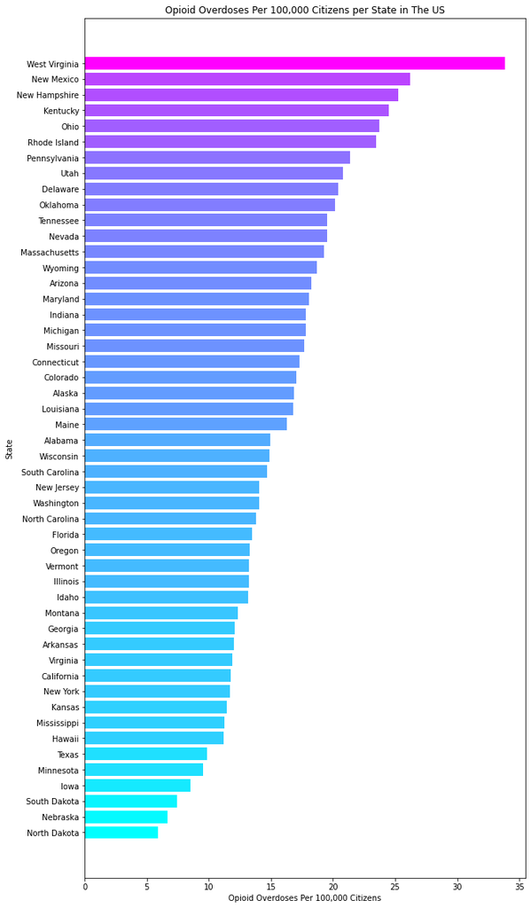

```python
### Plotting ###

# Plot Opioid Overdoses per 100,000 People split by State

# Documentation for matplotlib bar graph
# https://www.tutorialspoint.com/matplotlib/matplotlib_bar_plot.htm

# Sort Data
assendingDeaths = odData.sort_values(by="deathPer", ascending=True)

plt.figure(figsize = (10,20))

# Plot using horizontal Bar graph with gradient colormap
colormap = cm.get_cmap("cool", len(assendingDeaths["State"]))
rescale = lambda y: (y - np.min(y)) / (np.max(y) - np.min(y))
plt.barh(assendingDeaths["State"], assendingDeaths["deathPer"], color=colormap(rescale(assendingDeaths["deathPer"])))

# Label Plot
plt.ylabel("State")
plt.xlabel("Opioid Overdoses Per 100,000 Citizens")
plt.title("Opioid Overdoses Per 100,000 Citizens per State in The US")
plt.show()
```

Using the plot above, it can be seen that in 2014, West Virginia had the largest overdose proportion compared to any state.

### Interactive Map of Overdose Deaths

Next, we created an interactive map with each U.S. State in it with red being a higher overdose death proportion and white being less. In order to do this we got a json of the U.S. States from github, containing state border location data, and then graphed the overdose death per 100,000 people in each state on the map.

```python
# Plot Opioid Deaths per 100,000 People split by State On US Map

# Documentation for Folium for map plotting
# https://python-visualization.github.io/folium/

# Collect json file containing US State shape data
state_geo = "https://raw.githubusercontent.com/python-visualization/folium/master/examples/data/us-states.json"

# Print Title above map
print("Overdose Death Percentage Per State in the US".center(100))

# Create Color Bins for data
bins = list(odData["deathPer"].quantile([0, 0.15, 0.5, 0.7, 0.9, 1]))

# Create Map
m = folium.Map(location=[48, -102], zoom_start=3)

# Plot Overdose Data
folium.Choropleth(
    geo_data=state_geo,
    data=odData,
    columns=["Abbrev", "deathPer"],
    key_on="feature.id",
    fill_color="YlOrRd",
    fill_opacity=0.7,
    line_opacity=0.5,
    legend_name="Overdose Death Percentage (%)",
    bins=bins,
    reset=True,
).add_to(m)

m
```

```
                           Overdose Death Percentage Per State in the US
```

Make this Notebook Trusted to load map: File -> Trust Notebook

[interactive chart not shown]

This map limits the ability to compare states since each state is put into a certain range for coloring, however, it provides important information on physical locations for comparing states. On certain areas of the map, it is clear that certain clumps of states are greatly affected by overdose deaths such as Ohio, Kentucky, and West Virginia which all have high proportions of overdose deaths.

### Opioid Overdoses per 100,000 People and Proportion of Prescription Given that are Opioids by State

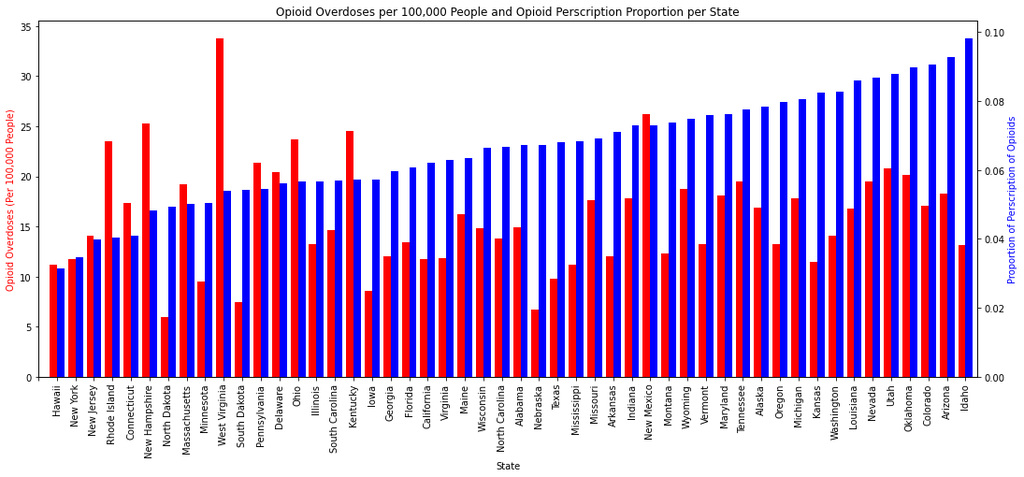

```python
# Plot Opioid Overdoses per 100,000 People and Proportion of Prescription Given that are Opioids by State

tempOd = odData[["State", "Abbrev", "deathPer"]].copy()

# Get prescription data and group by state to combine prescription numbers
presTemp = presData[["State", "numPresc", "numOpioidPresc"]].copy().groupby("State").sum()
stateData = pd.merge(left=tempOd, right=presTemp, left_on="Abbrev", right_on="State")

# Recalculate proportion of opioid prescription for entire state
stateData["opioidProp"] = stateData["numOpioidPresc"] / stateData["numPresc"]

# Clean and sort data
stateData = stateData.drop(["Abbrev", "numOpioidPresc", "numPresc"], axis=1)
stateData.sort_values(by=["opioidProp"], inplace=True)
stateData.reset_index(drop=True, inplace=True)

fig = plt.figure(figsize=(18,7))

# Create double bar graph
ax = fig.add_subplot(111)
ax2 = ax.twinx()

width = 0.4

# Plot each set of bars
stateData.deathPer.plot(kind="bar", color="red", ax=ax, width=width, position=1)
stateData.opioidProp.plot(kind="bar", color="blue", ax=ax2, width=width, position=0)

# Add blank label to create spacing on the left side of the plot
stateNames = [""] + stateData.State.tolist()

# Label X-axis
ax.set_xticks(range(-1,50))
ax2.set_xticks(range(-1,50))
ax.set_xticklabels(stateNames, rotation=90)
ax.set_xlabel("State")

# Label Y-axis
ax.set_ylabel("Opioid Overdoses (Per 100,000 People)")
ax.yaxis.label.set_color("red")
ax2.set_ylabel("Proportion of Perscription of Opioids")
ax2.yaxis.label.set_color("blue")

# Create Title
plt.title("Opioid Overdoses per 100,000 People and Opioid Perscription Proportion per State")

plt.show()
```

Looking at this plot, shows little relationship between the overdose deaths and the proportion of opioid prescriptions for each state. Specifically, it is shown that some states with very high overdose deaths, such as West Virginia, have lower proportions of opioid prescriptions for the state.

### Violin Plot of Opioid Prescription Proportion for each State

Previously, opiate prescription proportions were summarized for the state as a whole to simplify the data and prevent a situation where doctors that produce very few prescriptions but often having them be opiates, like a doctor doing 5 total prescriptions and 4 opiate prescriptions, be weighted the same as a doctor who prescribes many drugs and not many opiates. This has previously been ignored however prescribers may be having large effects of overdoses by prescribing few but only opiates. To visualize this, a violin plot is used where each violin represents a state and each data point is the proportion for each prescriber. The plot was sorted to match the prior graph, based on the state’s proportion of opiate prescriptions.

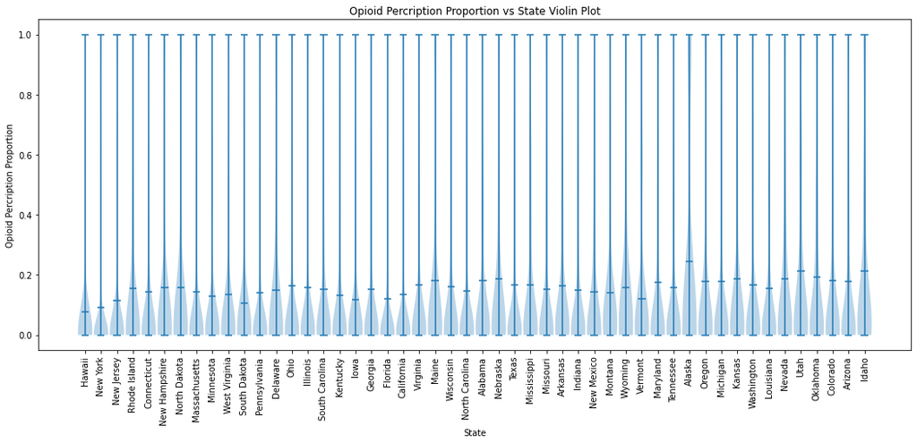

```python
# Violin Plot of Opioid Prescription Proportion for each State

# Documentation for violin plots through matplotlib
# https://matplotlib.org/stable/gallery/statistics/customized_violin.html

# Group Data by state and get Opioid Prescription Proportion into list for each State
violinDf = presData[["State", "opioidProp"]].copy().groupby("State")["opioidProp"].apply(list)
violinDf = pd.merge(left=tempOd, right=violinDf, left_on="Abbrev", right_on="State")

# Clean Data
violinDf.drop(["Abbrev", "deathPer"], axis=1, inplace=True)
violinDf.dropna(inplace=True)

# Sort Data based on Opioid Prescription Proportion for the entire State (Found using previous graph)
violinDf = violinDf.set_index("State")
violinDf = violinDf.reindex(index=stateData['State'])
violinDf = violinDf.reset_index()

# Get data in 2D list, each sublist representing the opioid prescription proportion for the corresponding state
violinData = violinDf["opioidProp"].tolist()

# Plot data
plt.figure(figsize=(18,7))
plt.violinplot(violinData, widths=0.9, showmeans=True)

# Label Plot
plt.xlabel("State")
plt.xticks(range(1,51), violinDf["State"], rotation=90)
plt.ylabel("Opioid Percription Proportion")
plt.title("Opioid Percription Proportion vs State Violin Plot")
plt.show()
```

The violin plot shows a few states with a high average proportion, such as Alaska, and some states that have large frequencies of high proportion prescribers, people that prescribe mostly opiates, also Alaska. Despite these worrying values for states like Alaska, the overdose deaths still do not match, as seen from the prior graph.

### Bar Chart of Opioid Prescription Proportion for Male vs Female Prescribers

Using the bar function and grouping the prescriber data by gender, we can compare males and females agains the proportion of opioid prescriptions they provide.

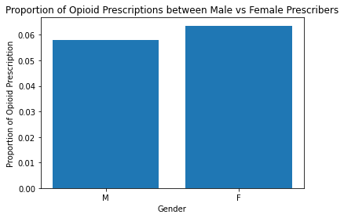

```python
# Bar Chart of Opioid Prescription Proportion for Male vs Female Prescribers

# Collect perscriber data and sum based on gender
presCopied = presData[["Gender", "numPresc", "numOpioidPresc"]].copy().groupby("Gender").sum()

# Plot Opioid Prescription Proportion split by Gender
plt.bar(presData["Gender"].unique(), presCopied["numOpioidPresc"]/presCopied["numPresc"])

# Label Plot
plt.xlabel("Gender")
plt.ylabel("Proportion of Opioid Prescription")
plt.title("Proportion of Opioid Prescriptions between Male vs Female Prescribers")
plt.show()
```

### Bar Chart of Opioid Prescription Proportion for Specialty

We also made a bar graph of the proportion of opioid prescriptions for each specialty to see which type of prescribers were most frequently prescribing opioids to their patients. We decided to use only the top 50 different specialties rather than all the specialties which were in the table to make the bar graph more readable.

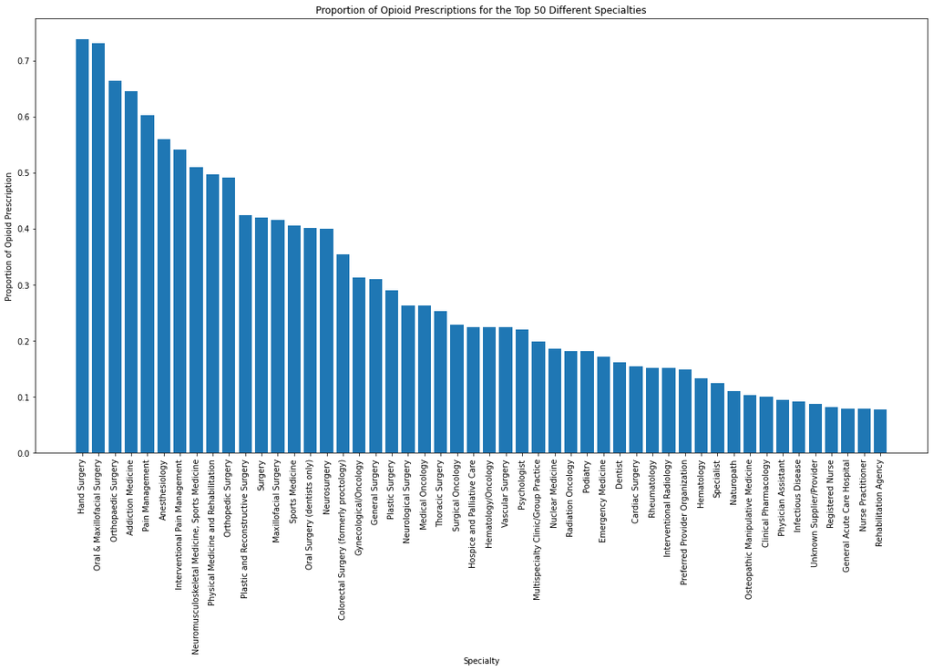

```python
# Bar Chart of Opioid Prescription Proportion for Specialty (Similar to state / death chart)

# Collect prescription data and sum by specialization
presTemp = presData[["Specialty", "numPresc", "numOpioidPresc"]].copy().groupby("Specialty").sum()
presTemp["OpioidProp"] = presTemp["numOpioidPresc"]/presTemp["numPresc"]
presTemp.sort_values(by=["OpioidProp"], inplace=True, ascending=False)

# Collect Specialties in sorted order
specialties = [];
for row, col in presTemp.iterrows():
  specialties.append(row)

plt.figure(figsize = (20,10))

# Plot Opioid Prescription Proportion for the Top 50 Specialty
plt.bar(specialties[:50], presTemp["OpioidProp"][:50])

# Label Plot
plt.xlabel("Specialty")
plt.xticks(rotation = 90)
plt.ylabel("Proportion of Opioid Prescription")
plt.title("Proportion of Opioid Prescriptions for the Top 50 Different Specialties")
plt.show()
```

### Histogram of Opiod Prescribers (Boolean of Over 10 Opioid Prescriptions) per State

As previously mentioned, our dataframe has a column, if an individual prescribed more than 10 opioids in a year. We used that column to create a histogram of the number of doctors per state which had over 10 opioid prescriptions in a year.

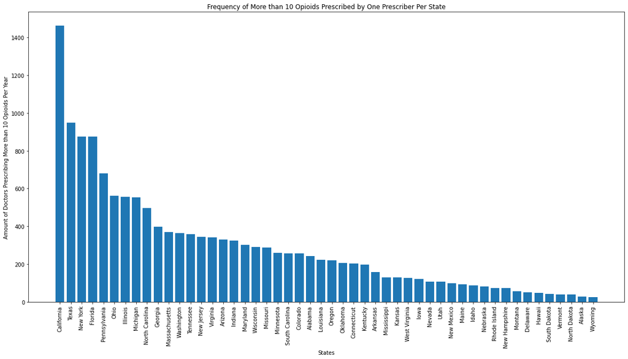

```python
# Histogram of Opiod Prescribers (Boolean of Over 10 Opioid Prescriptions) per State

# Collect prescription data and sum by state
tempOd = odData[["State", "Abbrev"]].copy()
presTemp = presData[["State", "Opioid.Prescriber"]].copy().groupby("State").sum()
stateData = pd.merge(left=tempOd, right=presTemp, left_on="Abbrev", right_on="State")

# Sort by number of Opiod Prescribers
stateData.sort_values(by=["Opioid.Prescriber"], inplace=True, ascending=False)

plt.figure(figsize = (20,10))

# Plot data by state
plt.bar(stateData["State"].unique(), stateData["Opioid.Prescriber"])

# Label Plot
plt.xlabel("States")
plt.xticks(rotation = 90)
plt.ylabel("Amount of Doctors Prescribing More than 10 Opioids Per Year")
plt.title("Frequency of More than 10 Opioids Prescribed by One Prescriber Per State")
plt.show()
```

As seen in the plot, California has the greatest number of doctors who prescribe over 10 opioids in a year followed by Texas and then New York. All of these states also, as shown in the first plot, are low for overdose deaths.

## Linear Regression

To test the effect of various pieces of data about prescribers on their proportion of opioid prescriptions, we used a linear regression. As inputs to the regression model, we used gender, whether they are an opioid prescriber as defined above, dummy columns for specialties, and dummy columns for states.

When conducting this linear regression, it was found that including dummy column for states had very little effect on the regression score and each state has a very small coefficient (meaning the state value did not change the output much). Increasing the number of dummy columns for specialties, does drastically increase the regression score to the 0.46 that it is currently at. Ultimately, the regression score of 0.46 is still small meaning there is not much correlation between the values of gender, opioid prescriber, specialties, and state to the opioid prescription proportion.

```python
### Linear Regression for Predicting Prescriber's Proportion of Opioid Perscriptions ###

# Get useful Data from Prescriber Data
tempPres = presData50[["Gender", "Specialty", "Opioid.Prescriber", "opioidProp", "Abbrev"]].copy()

# Create Dummy Columns for Top Specialities
linearDataSpec = tempPres.loc[tempPres["Specialty"].isin(specialties[:50])]
linearDummy = pd.get_dummies(linearDataSpec["Specialty"], drop_first=False, prefix="spec")
combined = pd.concat([tempPres, linearDummy], axis=1)

# Create Dummy Columns for States
#linearDummy = pd.get_dummies(tempPres["Abbrev"], drop_first=True, prefix="state")
#combined = pd.concat([combined, linearDummy], axis=1)

# Clean data for linear regression
combined.drop(["Specialty", "Abbrev"], axis=1, inplace=True)
combined.fillna(0, inplace=True)
combined["Gender"].replace("F", 0, inplace=True)
combined["Gender"].replace("M", 1, inplace=True)

# Feed into linear regression model
X = combined.drop(["opioidProp"], axis=1)
reg = LinearRegression().fit(X,combined["opioidProp"])

# Print line of best fit and regression score
line = "lifeExp = "
for col in range(len(X.columns)):
    line += X.columns[col] + " * " + str(round(reg.coef_[col] * 1000)/1000) + " +\n"
line += str(reg.intercept_)
print(line)
print("Regression Score: {}".format(round(reg.score(X,combined["opioidProp"]) * 1000)/1000))
```

```
lifeExp = Gender * 0.006 +
Opioid.Prescriber * 0.18 +
spec_Addiction Medicine * 0.475 +
spec_Anesthesiology * 0.306 +
spec_Cardiac Surgery * 0.157 +
spec_Clinical Pharmacology * -0.037 +
spec_Colorectal Surgery (formerly proctology) * 0.277 +
spec_Dentist * 0.095 +
spec_Emergency Medicine * 0.351 +
spec_General Acute Care Hospital * 0.107 +
spec_General Surgery * 0.507 +
spec_Gynecological/Oncology * 0.358 +
spec_Hand Surgery * 0.675 +
spec_Hematology * 0.144 +
spec_Hematology/Oncology * 0.109 +
spec_Hospice and Palliative Care * 0.317 +
spec_Infectious Disease * 0.017 +
spec_Interventional Pain Management * 0.474 +
spec_Interventional Radiology * 0.174 +
spec_Maxillofacial Surgery * 0.387 +
spec_Medical Oncology * 0.145 +
spec_Multispecialty Clinic/Group Practice * 0.325 +
spec_Naturopath * 0.127 +
spec_Neurological Surgery * 0.535 +
spec_Neuromusculoskeletal Medicine, Sports Medicine * 0.103 +
spec_Neurosurgery * 0.409 +
spec_Nuclear Medicine * 0.155 +
spec_Nurse Practitioner * 0.064 +
spec_Oral & Maxillofacial Surgery * 0.368 +
spec_Oral Surgery (dentists only) * 0.309 +
spec_Orthopaedic Surgery * 0.599 +
spec_Orthopedic Surgery * 0.492 +
spec_Osteopathic Manipulative Medicine * 0.108 +
spec_Pain Management * 0.459 +
spec_Physical Medicine and Rehabilitation * 0.29 +
spec_Physician Assistant * 0.173 +
spec_Plastic Surgery * 0.349 +
spec_Plastic and Reconstructive Surgery * 0.332 +
spec_Podiatry * 0.133 +
spec_Preferred Provider Organization * 0.411 +
spec_Psychologist * 0.043 +
spec_Radiation Oncology * 0.214 +
spec_Registered Nurse * 0.124 +
spec_Rehabilitation Agency * -0.004 +
spec_Rheumatology * 0.0 +
spec_Specialist * 0.13 +
spec_Sports Medicine * 0.263 +
spec_Surgery * 0.539 +
spec_Surgical Oncology * 0.455 +
spec_Thoracic Surgery * 0.391 +
spec_Unknown Supplier/Provider * -0.05 +
spec_Vascular Surgery * 0.211 +
-0.04942782891356862
Regression Score: 0.46
```